# Einstaklingsverkefni 3

ÁJG

2024-03-09

```r
library(tidyverse)
library(ggplot2)
```

```r
library(readr) # Lesum inn .csv skjal með upplýsingum um lestarferðir
subs <- read_csv("NYC_subway_traffic.csv")
```

#### Liður 1: Fjöldi innstiga á tiltekna lestarstöð klukkan 08

Breytan `entries.08` lýsir fjölda innstiga í tiltekna lest á tiltekinni lestarstöð klukkan 08:00 um morgun.

- Veljið ykkur eina lestarstöð (Stop Name) og búið til minna gagnasafn með eingöngu mælingum frá þeirri lestarstöð.

  ```r
  stop_23st <- subs %>%
                filter(`Stop Name` == "23 St")
  ```

- Teiknið graf sem sýnir fjölda innstiga klukkan 08 á þá lestarstöð.

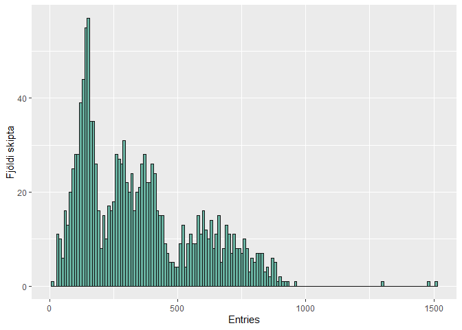

  ```r
  ggplot(data=stop_23st, aes(x= entries.08)) + geom_histogram(binwidth = 10, fill="#69b3a2", color="#111111") + labs(x= "Entries", y="Fjöldi skipta")
  ```

- Reiknið meðalfjölda innstiga á þessa tilteknu lestarstöð ásamt 95% öryggisbili

  ```r
  mean(stop_23st$entries.08) # Meðalfjöldi innstiga
  ```

  ```
  ## [1] 349.2483
  ```

  ```r
  t <- t.test(stop_23st$entries.08)


  print(t[["conf.int"]]) # 95% öryggisbil
  ```

  ```
  ## [1] 337.1494 361.3472
  ## attr(,"conf.level")
  ## [1] 0.95
  ```

- Lýsið útkomunni stuttlega

#### Liður 2: Samanburður á fjölda innstiga eftir gerð brautarpalla

Breytan `structure`lýsir því hvort brautarpallur tiltekinnar lestarstöðvar sé upphækkaður (elevated) eða neðanjarðar (subway).

- Veljið ykkur eina dagsetningu og búið til minna gagnasafn með eingöngu mælingum frá þessari dagsetningu (en frá öllum lestarstöðvum).

  ```r
  jan30 <- subs %>%
                filter(date == '2021-01-30')
  ```

- Teiknið graf sem ber saman fjölda innstiga á upphækkuðum brautarpöllum samanborið við neðanjarðarbrautarpalla.

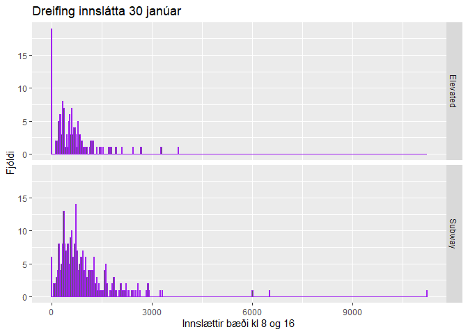

  ```r
  ggplot(jan30, aes(x=entries.08+entries.16 )) + geom_histogram(color="purple", binwidth = 30) + facet_grid( Structure ~ .) + labs(x="Innslættir bæði kl 8 og 16", y="Fjöldi", title = "Dreifing innslátta 30 janúar")
  ```

- Reiknið meðalfjölda innstiga klukkan 08 á morgnana fyrir hvora gerð af brautarpalli.

  ```r
  elevated <- jan30 %>% filter(Structure == "Elevated")
  subway <- jan30 %>% filter(Structure == "Subway")

  mean(subway$entries.08, na.rm= TRUE)
  ```

  ```
  ## [1] 299.3723
  ```

  ```r
  mean(elevated$entries.08, na.rm = TRUE)
  ```

  ```
  ## [1] 298
  ```

- Getið þið fullyrt að það sé munur á meðalfjölda innstiga eftir því af hvaða gerð brautarpallurinn er? Framkvæmið viðeigandi tilgátupróf til að kanna það og lýsið útkomunni

  ```r
  t.test(jan30$entries.08~ jan30$Structure)
  ```

  ```
  ##
  ##  Welch Two Sample t-test
  ##
  ## data:  jan30$entries.08 by jan30$Structure
  ## t = -0.034541, df = 342.67, p-value = 0.9725
  ## alternative hypothesis: true difference in means between group Elevated and group Subway is not equal to 0
  ## 95 percent confidence interval:
  ##  -79.51839  76.77371
  ## sample estimates:
  ## mean in group Elevated   mean in group Subway
  ##               298.0000               299.3723
  ```

*Sjáum að p-gildið er mjög hátt, þá getum við ályktað að enginn matktækur munur sé á ofanjarðar eða neðanjarðarpöllum. Þetta er svo staðfest með því að skoða öryggisbilið, sem inniheldur 0, sem þýðir að við getum ekki hafnað núlltilgátunni um að meðaltal innstiga sé jafnt.*

#### Liður 3: Samanburður á fjölda innstiga að morgni eða síðdegis

Breytan `entries.16` lýsir fjölda innstiga í tiltekna lest á tiltekinni lestarstöð klukkan 16:00 síðdegis.

- Veljið ykkur eitthvað eitt hverfi (Neighborhood) og búið til minna gagnasafn með eingöngu mælingum frá þessu hverfi.

  ```r
  eastharlem <- subs %>%
                filter(Neighborhood == 'East Harlem')
  ```

- Teiknið graf sem ber saman fjölda innstiga klukkan 08 á móti fjölda innstiga klukkan 16 í þessu hverfi.

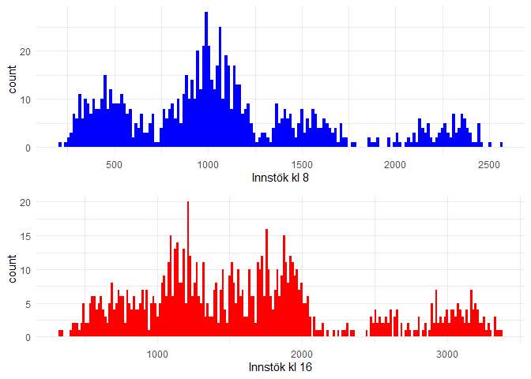

  ```r
  hist1 <- ggplot(eastharlem, aes(x=entries.08 )) + geom_histogram(binwidth = 15, fill="blue") +theme_minimal() + labs(x= "Innstök kl 8")


  hist2 <- ggplot(eastharlem, aes(x=entries.16)) + geom_histogram(binwidth = 15, fill="red") + theme_minimal() + labs(x= "Innstök kl 16")

  library(gridExtra)

  grid.arrange(hist1, hist2, nrow=2)
  ```

- Hvort eru fleiri innstig að morgni eða síðdegis í þessu hverfi? Framkvæmið viðeigandi tilgátupróf til að kanna það og lýsið útkomunni.

```r
wilcox.test(eastharlem$entries.08,eastharlem$entries.16)
```

```
##
##  Wilcoxon rank sum test with continuity correction
##
## data:  eastharlem$entries.08 and eastharlem$entries.16
## W = 225792, p-value < 2.2e-16
## alternative hypothesis: true location shift is not equal to 0
```

```r
sum(eastharlem$entries.08) # Innstig kl 8
```

```
## [1] 982019
```

```r
sum(eastharlem$entries.16) # Innstig kl 16
```

```
## [1] 1452474
```

*Sjáum að p-gildið er mjög lágt, sem bendir til þess að það sé lítil fylgni á milli meðaltala kl8 og kl 16. Það þýðir að það er munur á fjölda innstiga á morgnana og síðdeigis. Sjáum svo að mun fleiri taka lestina síðdeigis heldur en á morgnana í East Harlem.*